# Challenge 1

Manny Duran, Sally Rong, Jenny Wu. Xixi Zheng

2/10/2021

## Introduction

In this assignment, we use supervised learning methods to train and evaluate three different predictive models (logistic regression, Ridge regression, and boosted trees) to predict whether or not a criminal defendant will recidivate, utilizing data in the recidivism_data_sample.csv dataset. From the three models we train and evaluate, we proceed to select a final model to best deploy in the real world.

## Key Decision Made in Assesing our Models

In performing model evaluation to select our best model (boosted trees in our case), we consider two error metrics mainly: False Negative Rate (FNR) and Mean Squared Error (MSE). We care about a low FNR, because of the costs on society for having a high FNR. A low FNR is especially relevant in the context of predicting recidivism, because we do not wish to have wrongly predicted that an individual won’t recidivate when they do because that places a large cost to society as a whole. We optimize for a low FNR to lessen the probability of accidentally failing to account for an individual who will recidivate. We chose to set our threshold to 0.45 rather than the standard 0.5 after evaluating and comparing different FPR’s and FNR’s at different thresholds values to find the one with the smallest difference between FPRs and FNRs. We did this because we wanted to see if we could lower the FNR, which affects the cost of an individual who is wrongly classified as will recidivate in the future, while also making sure that in doing so, we do not add drastically to the FPR.

We also made the decision to evalute predicted probabilities with classification metrics because using predicted probability metrics allows us to assess how well the predicted values compare to true outcomes without having to choose thresholds. In this case, we looked at the MSE score. We chose MSE over alternatives because our outcome variable is binary, meaning that there are no outliers and that our data is not skewed. Mistakes made in prediction are all equally costly due to the binary nature of our outcome recidivate. In cases in which the outcome variable is binary (will recidivate or not), optimizing for a lower MSE is desirable. Additionally, we chose to look at predicted probability because our goal is not complete automation, but to provide an input into the richer decision making processes of court practices, procedures, and the judge’s expertise. Predicted probabilities allow for a more comprehensive understanding of information being presented compared to binary values.

## Data Set-up

```r
dat = read.csv("recidivism_data_sample.csv")
pseudo.dat = read.csv("recidivism_data_pseudo_new.csv")
dat = dat[,-1] #Taking out the ID variable because it isn't pertinent in our data.
dat$race = as.factor(dat$race)
set.seed(54321)
n.total <- nrow(dat)
prop.train <- 0.8
k <- sample(1:n.total, size = round(n.total*prop.train), replace = FALSE)
train.dat = dat[k,]
test.dat = dat[-k,]
```

```r
y <- dat$recidivate
x <- model.matrix(recidivate ~ ., data = dat)[,-1]

thresholds <- seq(from = 0.3, to = 0.7, by = 0.05)
set <- c("accuracy", "precision", "recall", "MSE", "FPR", "FNR", "Diff")
```

## Logistic Regression

```r
#modeling with a logistic regression, using family = "binomial" because our outcomes are binary
log1 = glm(recidivate ~., family = binomial(link = "logit"), data = train.dat)
# use logistic regression to predict on test data
mod2.pred = predict(log1, newdata = test.dat, type = "response")
```

# Metrics

```r
log.table <- data.frame(matrix(, nrow=9, ncol=7))
colnames(log.table) <- set
rownames(log.table) = thresholds
for(i in 1:length(thresholds)){
  mod2.class = as.numeric(mod2.pred >= thresholds[i]) # classifying predictions as recidivating or not
  TP<- sum(test.dat$recidivate == 1 & mod2.class == 1) # calculate true positives
  FP<- sum(test.dat$recidivate == 0 & mod2.class == 1) # calculate false positives
  TN<- sum(test.dat$recidivate == 0 & mod2.class == 0) # calculate true negatives
  FN<- sum(test.dat$recidivate == 1 & mod2.class == 0) # calculate false negatives
  accuracy <- (TP + TN)/ (TN + FN +TP +FP)
  precision <- (TP)/ (TP + FP)
  recall <- (TP)/ (TP + FN)
  MSE = mean((test.dat$recidivate - mod2.pred)^2)
  FPR <- FP / (FP +TN) # false positive rate
  FNR <- FN / (FN+TP) # false negative rate -- want a model with a low false negative rate
  diff = abs(FPR - FNR)
  log.table[i,] = cbind(accuracy, precision, recall, MSE, FPR, FNR, diff)
}

min.threshold = rownames(log.table)[which.min(log.table[,7])] #saving the threshold that gives us threshold that has the lowest absolute difference between FPR and FNR for comparison in the end
min.threshold
```

```
## [1] "0.45"
```

```r
log.table
```

```
##       accuracy precision    recall       MSE        FPR       FNR       Diff
## 0.3  0.5950000 0.5253863 0.8947368 0.2100388 0.64371257 0.1052632 0.53844942
## 0.35 0.6200000 0.5475000 0.8233083 0.2100388 0.54191617 0.1766917 0.36522444
## 0.4  0.6391667 0.5729013 0.7312030 0.2100388 0.43413174 0.2687970 0.16533474
## 0.45 0.6650000 0.6208178 0.6278195 0.2100388 0.30538922 0.3721805 0.06679123
## 0.5  0.6758333 0.6783042 0.5112782 0.2100388 0.19311377 0.4887218 0.29560803
## 0.55 0.6625000 0.7212544 0.3890977 0.2100388 0.11976048 0.6109023 0.49114178
## 0.6  0.6416667 0.7339450 0.3007519 0.2100388 0.08682635 0.6992481 0.61242177
## 0.65 0.6358333 0.7653631 0.2575188 0.2100388 0.06287425 0.7424812 0.67960695
## 0.7  0.6075000 0.7328244 0.1804511 0.2100388 0.05239521 0.8195489 0.76715366
```

# Logistic Calibration Plot

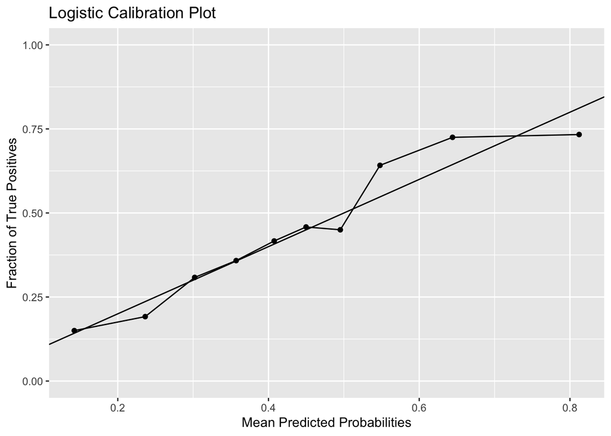

```r
# Creating the logistic calibration plot

data = cbind(test.dat, mod2.pred, mod2.class)
data$TP = as.numeric(test.dat$recidivate == 1 & mod2.class == 1) # generate column for true positives
risk_deciles = quantile(data$mod2.pred, probs = seq(from = 0, to = 1, by = 0.1)) # generate risk deciles, producing sample quantiles corresponding to probabilities from 0 to 1 in increments of 0.1

data$risk_decile_bin = as.numeric(cut(data$mod2.pred, breaks = risk_deciles, include.lowest = TRUE)) # create bins for risk deciles

some_results = data %>% group_by(risk_decile_bin) %>% summarise(pred.prob = mean(mod2.pred), pos = mean(recidivate)) #creating a new data table with the mean predicted probabilities and mean fraction of true positives separated into the 10 decile bins created in the previous line


ggplot(some_results, aes(x = pred.prob, y = pos)) + geom_point() + geom_line() +
  ggtitle("Logistic Calibration Plot") + ylim(0,1) + ylab("Fraction of True Positives") +
  xlab("Mean Predicted Probabilities") + geom_abline()
```

# Logistic Regression Evaluations

A logistic regression model is useful since our outcome variable is categorical. A logistic regression allows flexibility by producing a predicted probability for recidivism for each individual, which can then be used to produce classification while employing a threshold. The predicted probability estimates are kept within the bounds [0,1]. A logistic regression is also not computationally intensive, and is a flexible model, allowing that we add or drop coefficients with ease. However, this might also pose inefficiency, for the user has to manually decide which coefficients to keep or drop, and some predictors are factors with multiple levels. Another con to note with logistic regression is that it’s relatively low model complexity and easier explainability compromises model performance. It has a high FNR of 37.2%, which is not ideal, and one of the reasons we do not utilize logistic regression as our deployment model. The false positive rate (FPR) fares better at 30.5%, but we care more about FNR as an error metric in this context.

## Ridge Regression

```r
lambdas <- 10^seq(from = 6, to = -2, length = 100) # creating various lambda values
ridge.train <- glmnet(x = x[k,], y = y[k], alpha = 0, family = "binomial", lambda = lambdas) # creating ridge regression with family = "binomial" because our outcomes are binary
test.mse.ridge <- rep(NA,length(lambdas)) # empty object to use with function

for (i in 1:length(lambdas)){
  ridge.pred.test <- predict(ridge.train, newx = x[-k,], s = lambdas[i], type= "response") # use ridge regression model to predict onto test data iteratively with 1:i(length((lamdas)))
  test.mse.ridge[i] <- mean((y[-k] - ridge.pred.test)^2) # calculating mse for each iteration and storing it
}

min = lambdas[which.min(test.mse.ridge)] # locating the minimum test mse's and its optimal lamda value

ridge = glmnet(x = x[k,], y = y[k], alpha = 0, family = "binomial", lambda = min)# ridge regression model with optimal lambda value
ridge.pred = predict(ridge, newx = x[-k,], type = "response", s = min) # use ridge regression to predict onto test data
ridge.pred = as.vector(ridge.pred)
```